# Industry News

Vol. 76

J.H AHN

2022-07-27

## 잡설

한동안 R을 가까이 하지 못해서 퇴근 후 시간이 날 때마다 R로 통계처리하는 것을 연습하고 있습니다.

이번에는 R의 내장함수만 사용해서 통계처리하는 연습을 하는데, 얼마나 빠른 속도로 많은 것을 잊어버릴 수 있는지 알게 되어 놀랬고,

내장함수가 이렇게 강력했는지 몰랐다는 것에 대해서 한 번 더 놀랬습니다.

문제는 이것을 어떻게 업무와 잘 연결해서 사용할 수 있느냐인데 Power point를 잡고 있는 시간이 대부분이라 쉽지 않네요.

지난 주에 Morupule 3호기 문제를 이야기하면서 k-means clustering을 간만에 해봤는데… 뿌듯함과 함께 반가움이 밀려왔습니다.

문득문득 설계팀에서 운전데이터 분석할 때가 그리워지곤 합니다.

### 하나 - How to tell data-driven stories

아시아의 데이터 스토리텔링 콘텐츠사 ’Kontinentalist’가 진행한 시각화 워크샵에 대한 글입니다.

이런 주제로 회사를 운영할 수 있다는 것과 수요가 있다는 것이 놀라웠습니다.

글에 보면 효과적인 데이터 스토리텔링을 위해서는 ’인포그래픽과 데이터 시각화의 차이’를 명확하게 하고 ’직관적인 컬러’를 사용해야 한다고 합니다.

[Medium 글](https://medium.com/kontinentalist/how-to-tell-data-driven-stories-fc5a19af09f0)

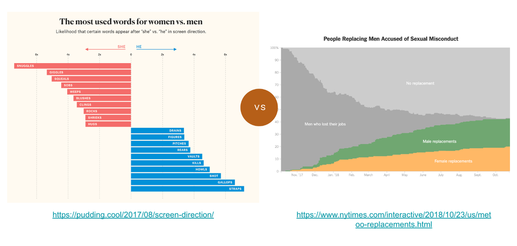

흥미로운 것이 데이터 시각화라 하면 우리는 운전데이터, 뭔가 방대하고 엄청난 것을 생각하곤 하는데 자신이 가 본 여행장소, 인생의 기억할 만한 순간, 음악을 들으며 느낀 감정등과 같은 일상경험을 시각화 한 것이었습니다.

저부터도 뭔가 데이터를 시각화해서 시사점을 던져주고 결과를 찾아야 한다는 강박에 빠져있었던 것이 아닌가 싶은 생각도 들었고, EDA(exploratory data analysis, 탐색적 데이터 분석)이란 말처럼 데이터를 탐색해 가다보면 생각치 못한 의미가 찾아지는 것인데 시작부터 선입견과 편견에 사로잡혀 원하는 방향으로 결과를 가져오려 했던 것이 아닌가 하는 반성을 하게되었습니다.

### 둘 - 인공지능 ‘람다’, “지각이 있다” 주장한 구글연구원 해고!

[관련기사](http://www.aitimes.kr/news/articleView.html?idxno=25614)

구글의 인공지능 ’람다’가 지각이 있다고 주장했던 르모인 구글AI 연구원이 결국 해고당했습니다.

사실 이런 일이 언젠가는 있을거라 예상을 했지만, 그게 2022년일 줄은 생각도 못했습니다.

영화 Her가 이렇게 빨리 현실이 될 줄은 상상도 못했습니다.

늘 그러하듯 세상은 제가 모르는 사이에 상상도 못할 속도로 바뀌고 있고,

인류는 문제를 만들고, 그리고 해결책을 찾아냅니다.

이제 곧 AI가 지능과 인격을 가진다고 논쟁하는 일조차 무의미해 질 시점이 멀지 않은 것 같다는 생각이 들었습니다.

커즈와일의 ’특이점이 온다’에서 2042년인가에 초지능의 탄생을 예고했는데… 더 이상 허황되게 느껴지지 않고 있습니다.

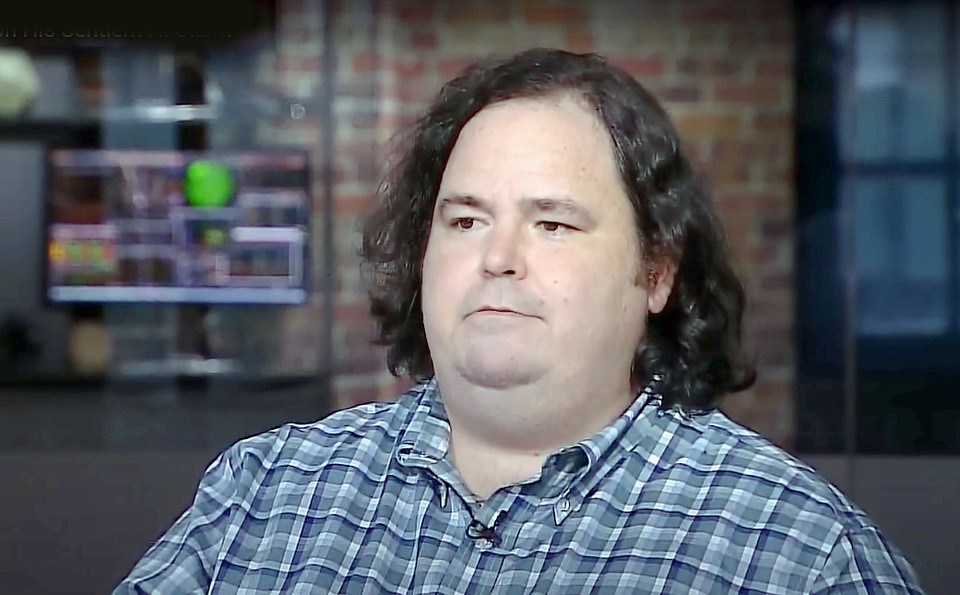

## 새로운 소식들

### Kairos Commissions Molten Salt Coolant Production Plant for High-Temperature Nuclear Reactors

[기사링크](https://www.powermag.com/kairos-commissions-molten-salt-coolant-production-plant-for-high-temperature-nuclear-reactors/)

원자로 개발업체인 Kairos Power는 fluoride salt-cooled, high-temperature reactor (KP-FHR)에 기반한 원자로를 대량 생산하기 위한 molten salt purification plant (MSPP) 시운전에 들어감.

KP-FHR 기술은 본질적으로 Flibe molten fluoride salt coolant와 함께 흑연 감속재, “무작위로 채워진” 자갈층 원자로로 구성.

KP-FHR 원자로는 고온 및 대기압에 가까운 압력에서 작동

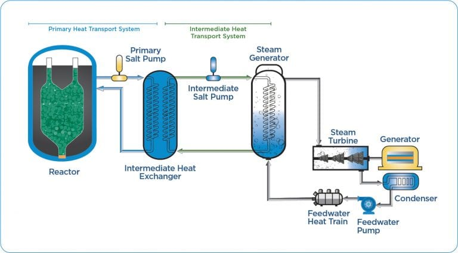

Kairos의 진행 상황은 지금까지 뉴멕시코주 앨버커키에 있는 Kairos의 KP-Southwest 연구 개발 시설에서 열릴 non-nuclear, unenriched Flibe-wetted, isothermal integrated test인 ETU(Engineering Test Unit)에 집중

Kairos는 Oak Ridge의 East Tennessee Technology Park(ETTP)에서 KP-FHR 설계를 기반으로 하는 50MWth 원자로를 테스트 할 준비 중에 있음

[참고링크](https://www.powermag.com/nrc-accepts-application-for-kairos-pebble-bed-reactor-construction-permit/)

### Georgia Power launches coal ash use project at Plant Bowen

조금 지난 소식이지만 흥미로운 내용이라 가져왔습니다.

[기사링크](https://www.power-eng.com/coal/georgia-power-launches-coal-ash-use-project-at-plant-bowen/)

유틸리티 및 Eco Material Technologies와 관련된 프로젝트에 따라 Georgia Power의 Plant Bowen에서 석탄재를 받아 재활용

석탄재는 조지아와 남동부의 교량, 도로 및 건물을 건설하기 위해 콘크리트에 사용될 예정

석탄재는 강도와 내구성을 추가하는 콘크리트와 같은 특정 제품에 상당한 가치를 제공하는 것으로 입증되었음

Georgia Power는 이를 미국에서 single largest beneficial use 프로젝트이자 전력회사로서는 가장 큰 규모라고 발표

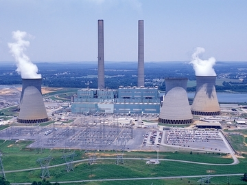

지속 가능한 시멘트 재료 및 시멘트 대체 제품을 생산하는 Eco Material Technologies가 Plant Bowen에서 프로젝트를 관리 중

이는 Georgia Power 가 EPRI(Electric Power Research Institute)와 제휴 하여 석탄재의 유익한 용도를 식별, 테스트 및 가속화하기 위해 Plant Bowen에 연구 시설을 개설한 이후의 개발된 것으로 이 시설은 석탄재의 재활용 및 사용을 지속적으로 증가시키기 위한 파일럿 프로젝트 및 기술 테스트가 허용되어 있음

### 적자보는 양수발전·ESS 누가 투자하나

[기사링크](http://www.e2news.com/news/articleView.html?idxno=243802)

기사 중 일부 발췌

각 국은 유연성과 경제성, 친환경성 등을 두루 갖춘 대용량 ESS 확보에 나서고 있다. 우선 재생에너지 설비 비중이 40%에 이르는 중국은 2030년 양수설비 120GW, 배터리 100GW 확대를 목표로 34개 지역에 신규 양수를 건설하고 있다.

지난해 준공한 허베이성 펑닝 양수의 경우 설비량 3.6GW, 저장량 18GWh규모로 세계에서 가장 크다. 중국은 작년말 36GW인 설비를 2025년 62GW, 2030년 120GW, 2035년 300GW 순으로 늘린다는 목표 아래 재생에너지 ESS확보 의무를 부과하고 시장제도를 정비하고 있다.

미국도 대용량 ESS 확충에 속도를 내고 있다. 현재 90건, 80GW규모 신규양수 프로젝트가 예비 및 본허가 심사를 받고 있다. 주(州)별 2030년 ESS(배터리포함) 목표는 캘리포니아 1GW, 뉴욕 6GW, 뉴저지 2GW, 네바다 1GW, 버지니아 3GW, 코네티컷 1GW, 미시건 2.5GW 등이다.

앞서 미 NREL(국립재생에너지연구소)은 2050 탄소중립을 위해 모두 250~630GW의 ESS가 필요하다는 보고서를 냈다. 2020년말 현재 미국 양수설비량은 22GW이며, 2050년 예상 설비량은 최대 150GW이다.

한때 54기의 원전을 운영하면서 양수설비를 27GW까지 늘린 일본은 다소 여유롭다. 2.3GW의 설비를 보유한 규슈지역은 2012년 대비 양수운전횟수를 30배 늘려 태양광 발전의 변동성을 감당하고 있다. 이 지역의 태양광 발전량은 피크수요의 65~85%를 점유하고 있다.

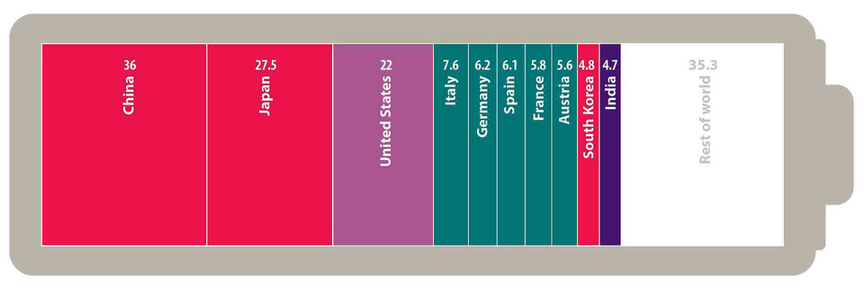

김은수 한국수력산업협회 상근부회장은 “ESS없이는 탄소중립 전력망 운영이 어려운데 아직 우리나라는 그에 관한 본격 논의를 시작하지 못한 상태”라면서 “양수의 경우 앞으로는 고정비가 20~30% 더 비싼 가변속설비가 필요하다. 시장에서 생존여건이 안되면 아무도 신규투자에 나서지 않으려 할 것”이라고 지적했다.

## 전력시장

### Wordcloud for Enerbility

[interactive chart not shown]

### 전력계통

<변동내역>

- 중앙급전발전기 : 변동사항 없음
- 비중앙급전발전기 : 태양5호태양광발전소 신설 등[+3.4MW]

**best regards,**  
**J.H**

**Industry News?**  
매주 전력산업의 새로운 소식과 산업계 동향을 공유하는 뉴스레터입니다.  
Feedback은 언제라도 환영합니다.  
📫 junho.ahn@doosan.com

**END**